# Feelings and Vote Choice

For this project I am interested in how much feelings towards the political parties matter when it comes to presidential vote choice. I am interested in comparing the impact of feelings to more traditional variables such as policy preferences. Taking data from the 2016 ANES I run several logistic regression models in which I attempt to predict a respondents vote choice based on their 1) feelings 2) policy preferences 3) and demographics.

```r
rm(list = ls())
setwd("C:/Users/cayde/OneDrive/Graduate Studies/Misc/TA/Lab 102/Data Sets")
library(ggplot2)
library(dplyr)
library(e1071)
library(randomForest)

anes <- read.csv("anes_timeseries_2016.csv")
```

The data is from the American National Election Services, so it is already in a clean format. First thing I do is inspect the data and see which columns have the most missing data.

```r
#Inspecting the Data
#####################

head(anes)
```

|  | case_ID | pay_attn_to_politics | vote_in_2012 | vote_choice_2012 | attn_to_news | registered_to_vote | party_of_registration | vote_in_primary | vote_choice_primary | vote_for_president | vote_choice_president | approve_of_congress | country_on_track | approve_of_president | feeling_dem_cand | feeling_rep_cand | feeling_prev_pres | feeling_bill_clinton | feeling_dem_party | feeling_rep_party | have_health_insurance | favor_2010_health_care_law | liberal.cons_self | current_econ | party_better_economy | importance_of_guns | policy_immigrants | build_wall | speak_english | … |
| --- | --- | --- | --- | --- | --- | --- | --- | --- | --- | --- | --- | --- | --- | --- | --- | --- | --- | --- | --- | --- | --- | --- | --- | --- | --- | --- | --- | --- | --- | --- |
| 1 | 1 | 3. About half the time | 2. No, didn't vote | NA | 4. A little | 1. Registered | 2. Republican party | 2. No, didn't vote in primary or caucus | NA | 1. Yes | 2. Donald Trump | 2. Disapprove | 2. Wrong track | 2. Disapprove | 0 | 85 | 0 | 15 | 0 | 70 | 2. Oppose | 2. Oppose | NA | 5. Very bad | 2. Republicans | 2. Very important | 3. Allow to remain and eventually qualify for U.S. citizenship, if they meet | 1. Favor | 2. Somewhat important | … |
| 2 | 2 | 1. Always | 1. Yes, voted | 1. Barack Obama | 1. A great deal | 1. Registered | 3. None or 'independent' | 2. No, didn't vote in primary or caucus | NA | 1. Yes | 2. Donald Trump | 2. Disapprove | 2. Wrong track | 2. Disapprove | 0 | 85 | 30 | 50 | 15 | 85 | 3. Neither favor nor oppose | 3. Neither favor nor oppose | 5. Slightly conservative | 3. Neither good nor bad | 3. Not much difference between them | 1. Extremely important | 1. Make all unauthorized immigrants felons and send them back to their home country. | 1. Favor | 1. Very important | … |
| 3 | 3 | 4. Some of the time | 2. No, didn't vote | NA | 4. A little | 2. Not registered | NA | 2. No, didn't vote in primary or caucus | NA | NA | NA | 2. Disapprove | 2. Wrong track | 2. Disapprove | 50 | 60 | 30 | 50 | 50 | 50 | 1. Favor | 1. Favor | NA | 4. Bad | 2. Republicans | 2. Very important | 1. Make all unauthorized immigrants felons and send them back to their home country. | 2. Oppose | 1. Very important | … |
| 4 | 4 | 3. About half the time | 1. Yes, voted | 2. Mitt Romney | 2. A lot | 1. Registered | NA | 2. No, didn't vote in primary or caucus | NA | NA | NA | 1. Approve | 2. Wrong track | 2. Disapprove | 0 | 60 | 15 | 50 | 30 | 70 | 2. Oppose | 2. Oppose | NA | 3. Neither good nor bad | 2. Republicans | 1. Extremely important | 3. Allow to remain and eventually qualify for U.S. citizenship, if they meet | 3. Neither favor nor oppose | 1. Very important | … |
| 5 | 5 | 3. About half the time | 1. Yes, voted | 1. Barack Obama | 3. A moderate amount | 1. Registered | NA | 2. No, didn't vote in primary or caucus | NA | 1. Yes | 3. Gary Johnson | 2. Disapprove | 2. Wrong track | 2. Disapprove | 15 | 0 | 40 | 70 | 70 | 40 | 3. Neither favor nor oppose | 3. Neither favor nor oppose | 4. Moderate, middle of the road | 4. Bad | 2. Republicans | 1. Extremely important | 3. Allow to remain and eventually qualify for U.S. citizenship, if they meet | 2. Oppose | 4. Not at all important | … |
| 6 | 6 | 1. Always | 1. Yes, voted | 2. Mitt Romney | 1. A great deal | 1. Registered | 3. None or 'independent' | 2. No, didn't vote in primary or caucus | NA | NA | NA | 2. Disapprove | 2. Wrong track | 2. Disapprove | 0 | 50 | 0 | 40 | 15 | 30 | 2. Oppose | 2. Oppose | 6. Conservative | 4. Bad | 2. Republicans | 2. Very important | 3. Allow to remain and eventually qualify for U.S. citizenship, if they meet | 1. Favor | 1. Very important | … |

```r
str(anes)
```

```
'data.frame':   4270 obs. of  50 variables:
 $ case_ID                        : int  1 2 3 4 5 6 7 8 9 10 ...
 $ pay_attn_to_politics           : chr  "3. About half the time" "1. Always" "4. Some of the time" "3. About half the time" ...
 $ vote_in_2012                   : chr  "2. No, didn't vote" "1. Yes, voted" "2. No, didn't vote" "1. Yes, voted" ...
 $ vote_choice_2012               : chr  NA "1. Barack Obama" NA "2. Mitt Romney" ...
 $ attn_to_news                   : chr  "4. A little" "1. A great deal" "4. A little" "2. A lot" ...
 $ registered_to_vote             : chr  "1. Registered" "1. Registered" "2. Not registered" "1. Registered" ...
 $ party_of_registration          : chr  "2. Republican party" "3. None or 'independent'" NA NA ...
 $ vote_in_primary                : chr  "2. No, didn't vote in primary or caucus" "2. No, didn't vote in primary or caucus" "2. No, didn't vote in primary or caucus" "2. No, didn't vote in primary or caucus" ...
 $ vote_choice_primary            : chr  NA NA NA NA ...
 $ vote_for_president             : chr  "1. Yes" "1. Yes" NA NA ...
 $ vote_choice_president          : chr  "2. Donald Trump" "2. Donald Trump" NA NA ...
 $ approve_of_congress            : chr  "2. Disapprove" "2. Disapprove" "2. Disapprove" "1. Approve" ...
 $ country_on_track               : chr  "2. Wrong track" "2. Wrong track" "2. Wrong track" "2. Wrong track" ...
 $ approve_of_president           : chr  "2. Disapprove" "2. Disapprove" "2. Disapprove" "2. Disapprove" ...
```

[output cut: 36 more lines]

```r
sapply(anes, class) #look at the data types
```

```
                        case_ID            pay_attn_to_politics                    vote_in_2012                vote_choice_2012                    attn_to_news
                      "integer"                     "character"                     "character"                     "character"                     "character"
             registered_to_vote           party_of_registration                 vote_in_primary             vote_choice_primary              vote_for_president
                    "character"                     "character"                     "character"                     "character"                     "character"
          vote_choice_president             approve_of_congress                country_on_track            approve_of_president                feeling_dem_cand
                    "character"                     "character"                     "character"                     "character"                       "integer"
               feeling_rep_cand               feeling_prev_pres            feeling_bill_clinton               feeling_dem_party               feeling_rep_party
                      "integer"                       "integer"                       "integer"                       "integer"                       "integer"
          have_health_insurance      favor_2010_health_care_law               liberal.cons_self                    current_econ            party_better_economy
                    "character"                     "character"                     "character"                     "character"                     "character"
             importance_of_guns               policy_immigrants                      build_wall                   speak_english                 syrian_refugees
                    "character"                     "character"                     "character"                     "character"                     "character"
           gov_waste_.tax_money                  global_warming                   death_penalty                     obama_angry                     obama_proud
                    "character"                     "character"                     "character"                     "character"                     "character"
             religion_important                   attend_church             attend_church_often            born_again_christian                             age
                    "character"                     "character"                     "character"                     "character"                       "integer"
                        married                       education                        hispanic                           white                   black.af.amer
                    "character"                     "character"                     "character"                     "character"                     "character"
            amer.indian.alaskan                           asian hawaiian.pac.islander.mentioned           native_status_parents    grandparents_born_outside_US
                    "character"                     "character"                     "character"                     "character"                     "character"
```

```r
sort(sapply(anes, function(x){mean(is.na(x))*100})) #get a sense of which columns are missing data
```

```
                        case_ID            pay_attn_to_politics                   attend_church      favor_2010_health_care_law                 vote_in_primary
                     0.00000000                      0.00000000                      0.00000000                      0.09367681                      0.14051522
                  speak_english              registered_to_vote                    current_econ           have_health_insurance              importance_of_guns
                     0.16393443                      0.18735363                      0.21077283                      0.23419204                      0.30444965
                       hispanic                    vote_in_2012                      build_wall               feeling_prev_pres            gov_waste_.tax_money
                     0.32786885                      0.37470726                      0.44496487                      0.49180328                      0.60889930
             religion_important                         married                     obama_proud           native_status_parents                     obama_angry
                     0.63231850                      0.63231850                      0.74941452                      0.74941452                      0.77283372
           party_better_economy                country_on_track            feeling_bill_clinton                 syrian_refugees                feeling_dem_cand
                     0.79625293                      0.81967213                      0.84309133                      0.84309133                      0.88992974
               feeling_rep_cand                       education            approve_of_president    grandparents_born_outside_US                  global_warming
                     0.96018735                      1.03044496                      1.07728337                      1.14754098                      1.31147541
              policy_immigrants                           white                   black.af.amer             amer.indian.alaskan                           asian
                     1.38173302                      1.40515222                      1.40515222                      1.40515222                      1.40515222
hawaiian.pac.islander.mentioned               feeling_dem_party                    attn_to_news               feeling_rep_party                   death_penalty
                     1.40515222                      1.63934426                      1.82669789                      2.01405152                      2.10772834
                            age             approve_of_congress              vote_for_president               liberal.cons_self           vote_choice_president
                     2.83372365                      3.37236534                     13.23185012                     22.64637002                     23.13817330
               vote_choice_2012            born_again_christian             attend_church_often           party_of_registration             vote_choice_primary
                    28.47775176                     30.79625293                     40.32786885                     50.84309133                     56.13583138
```

```r
summary(anes$feeling_dem_party)
```

```
   Min. 1st Qu.  Median    Mean 3rd Qu.    Max.    NA's
   0.00   25.00   50.00   48.17   70.00  100.00      70
```

```r
summary(anes$feeling_rep_party)
```

```
   Min. 1st Qu.  Median    Mean 3rd Qu.    Max.    NA's
   0.00   17.00   50.00   43.51   60.00  100.00      86
```

Next I split the data into training and test sets.

```r
#Splitting data
###################

set.seed(452)
anes$assignment <- sample(c("training", "test"), nrow(anes), replace=TRUE, prob = c(0.7, 0.3))
```

Here I do some simple transformations on my Dependent Variable (2016 Vote choice). I drop third party candidates and rename the values to something more concise.

```r
#Data Transformation
####################

table(anes$vote_choice_president)
```

```
1. Hillary Clinton    2. Donald Trump    3. Gary Johnson      4. Jill Stein           5. Other
              1570               1357                227                 57                 71
```

```r
anes_2party <- filter(anes, vote_choice_president == '1. Hillary Clinton' | vote_choice_president == '2. Donald Trump')
anes_2party$vote_choice_president <- recode(anes_2party$vote_choice_president, "1. Hillary Clinton" = "Clinton", "2. Donald Trump" = "Trump")
table(anes_2party$vote_choice_president)
```

```
Clinton   Trump
   1570    1357
```

```r
anes_2party$vote_choice_president <- as.factor(anes_2party$vote_choice_president)
```

Before estimating the models I am interested in how the data looks. I create a simple bivariate scatterplot plotting the feelings for the different parties, and I color the dots by vote choice.

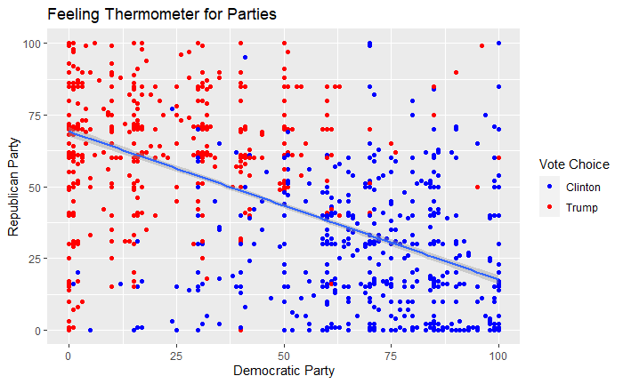

```r
#Data Visualization

ggplot(data = anes_2party, mapping = aes(x = feeling_dem_party, y = feeling_rep_party)) +
  geom_point(aes(color = vote_choice_president)) +
  geom_smooth(method='lm') +
  scale_color_manual(values = c("blue", "red", "gray", "gray")) +
  xlab("Democratic Party") +
  ylab("Republican Party") +
  ggtitle("Feeling Thermometer for Parties") +
  guides(color = guide_legend("Vote Choice"))
```

For this project I am largely interested in how well the feelings for the parties predict vote choices, and how this compares to policies. Traditional understandings of democracy assume that citizens vote for the candidate that most closely aligns with their policy preferences, and makes no mention of feelings. In this polarized environment I believe that feelings are very prominent in politics.

For my first model, I estimate a logistic regression in which vote choice is the DV and feelings towards the 2 political parties are the predicting variables. I use the fitted model to make predictions on vote choice for the tested data.

```r
################
#Classification
################

#Feelings
#########


DV <- "vote_choice_president"
feeling_variables <- c("feeling_dem_party", "feeling_rep_party")

#Subsetting the data by relevant variables and removing NA's
anes_2party_feelings <- subset(anes_2party, select = c(DV, feeling_variables, "assignment"))
anes_2party_feelings <- na.omit(anes_2party_feelings)

#Splitting the new data into testing and training sets based on previous assignment
anes_2party_feelings_train <- filter(anes_2party_feelings, assignment == "training")
anes_2party_feelings_train <- subset(anes_2party_feelings_train, select = c(DV, feeling_variables))

anes_2party_feelings_test <- filter(anes_2party_feelings, assignment == "test")
anes_2party_feelings_test <- subset(anes_2party_feelings_test, select = c(DV, feeling_variables))

#Estimating a model on the training set
logit_feelings <- glm(vote_choice_president ~ .,
                      data = anes_2party_feelings_train,
                      family = "binomial")

predictions_feelings <- round(predict.glm(logit_feelings, newdata = anes_2party_feelings_test, type = "response"))
predictions_feelings[predictions_feelings == 0] <- "Clinton"
predictions_feelings[predictions_feelings == 1] <- "Trump"

table(predictions_feelings, anes_2party_feelings_test$vote_choice_president)
```

```
predictions_feelings Clinton Trump
             Clinton     449    25
             Trump        54   388
```

Taking only feelings into account, the model has an impressive 91% accuracy.

Next I look at policy. The ANES asks policy opinions on a variety of issues, such as opinions on building the wall, the 2010 health care law, global warming, etc. I am interested in how well policy preferences predict vote choices.

```r
#Policy
#######

#Identifying the relevant variables for the model
policy_variables <- c("have_health_insurance", "favor_2010_health_care_law",
                        "party_better_economy", "importance_of_guns", "policy_immigrants",
                        "build_wall", "speak_english", "syrian_refugees", "gov_waste_.tax_money",
                        "global_warming", "death_penalty")

#Subsetting the data by relevant variables and removing NA's
anes_2party_policy <- subset(anes_2party, select = c(DV, policy_variables, "assignment"))
anes_2party_policy <- na.omit(anes_2party_policy)

#Splitting the new data into testing and training sets based on previous assignment
anes_2party_policy_train <- filter(anes_2party_policy, assignment == "training")
anes_2party_policy_train <- subset(anes_2party_policy_train, select = c(DV, policy_variables))

anes_2party_policy_test <- filter(anes_2party_policy, assignment == "test")
anes_2party_policy_test <- subset(anes_2party_policy_test, select = c(DV, policy_variables))

#Estimating a model on the training set
logit_policy <- glm(vote_choice_president ~ .,
                      data = anes_2party_policy_train,
                      family = "binomial")

predictions_policy <- round(predict.glm(logit_policy, newdata = anes_2party_policy_test, type = "response"))
predictions_policy[predictions_policy == 0] <- "Clinton"
predictions_policy[predictions_policy == 1] <- "Trump"

table(predictions_policy, anes_2party_policy_test$vote_choice_president)
```

```
predictions_policy Clinton Trump
           Clinton     446    40
           Trump        37   368
```

The policy model is almost identical with a 91% accuracy. This shows that feelings are just as predictive of vote choice as policy preferences.

Finally I estimate a model with demographics. I do not expect this model to be as accurate, but I am interested in how well it predicts vote choice.

```r
#Demographics

#Subsetting the data by relevant variables and removing NA's
demographic_variables <- c("religion_important", "age", "married", "education", "hispanic", "white")

anes_2party_demo <- anes_2party %>%
  subset(select = c(DV, demographic_variables, "assignment")) %>%
  na.omit()

#Splitting the new data into testing and training sets based on previous assignment
anes_2party_demo_train <- anes_2party_demo %>%
  filter(assignment == "training") %>%
  subset(select = c(DV, demographic_variables))

anes_2party_demo_test <- anes_2party_demo %>%
  filter(assignment == "test") %>%
  subset(select = c(DV, demographic_variables))

#Estimating a model on the training set
logit_demographics <- glm(vote_choice_president ~.,
                          data = anes_2party_demo_train,
                          family = "binomial")

predictions_demographics <- round(predict.glm(logit_demographics, newdata = anes_2party_demo_test, type = "response"))
predictions_demographics[predictions_demographics == 0] <- "Clinton"
predictions_demographics[predictions_demographics == 1] <- "Trump"

table(predictions_demographics, anes_2party_demo_test$vote_choice_president)
```

```
predictions_demographics Clinton Trump
                 Clinton     339   117
                 Trump       142   286
```

Finally I am interested in predicting vote choice as accurately as possible. Normally I would include partisanship and ideology in this model, but the ANES set is missing a lot of data from these variables. The next model is simply a logistic regression with feelings, policy preferences, and demographics all entered.

```r
#Full Model

sapply(anes_2party, function(x){mean(is.na(x))})
```

```
                        case_ID            pay_attn_to_politics                    vote_in_2012                vote_choice_2012                    attn_to_news
                   0.0000000000                    0.0000000000                    0.0023915272                    0.1844892381                    0.0099077554
             registered_to_vote           party_of_registration                 vote_in_primary             vote_choice_primary              vote_for_president
                   0.0006832935                    0.4543901606                    0.0006832935                    0.4752306115                    0.0000000000
          vote_choice_president             approve_of_congress                country_on_track            approve_of_president                feeling_dem_cand
                   0.0000000000                    0.0228903314                    0.0061496413                    0.0034164674                    0.0075162282
               feeling_rep_cand               feeling_prev_pres            feeling_bill_clinton               feeling_dem_party               feeling_rep_party
                   0.0068329347                    0.0023915272                    0.0058079945                    0.0095661086                    0.0126409293
          have_health_insurance      favor_2010_health_care_law               liberal.cons_self                    current_econ            party_better_economy
                   0.0017082337                    0.0006832935                    0.1885889990                    0.0017082337                    0.0047830543
             importance_of_guns               policy_immigrants                      build_wall                   speak_english                 syrian_refugees
                   0.0017082337                    0.0105910489                    0.0030748206                    0.0010249402                    0.0068329347
           gov_waste_.tax_money                  global_warming                   death_penalty                     obama_angry                     obama_proud
                   0.0040997608                    0.0078578750                    0.0143491630                    0.0037581141                    0.0030748206
             religion_important                   attend_church             attend_church_often            born_again_christian                             age
                   0.0040997608                    0.0000000000                    0.3836692860                    0.2835667919                    0.0228903314
                        married                       education                        hispanic                           white                   black.af.amer
                   0.0051247011                    0.0081995217                    0.0013665869                    0.0095661086                    0.0095661086
            amer.indian.alaskan                           asian hawaiian.pac.islander.mentioned           native_status_parents    grandparents_born_outside_US
                   0.0095661086                    0.0095661086                    0.0095661086                    0.0051247011                    0.0088828152
                     assignment
                   0.0000000000
```

```r
anes_2party_full <- anes_2party %>%
  subset(select = c(DV, policy_variables, feeling_variables, demographic_variables, "assignment")) %>%
  na.omit()

#Splitting the new data into testing and training sets based on previous assignment
anes_2party_full_train <- anes_2party_full %>%
  filter(assignment == "training") %>%
  subset(select = c(DV, policy_variables, feeling_variables, demographic_variables))

anes_2party_full_test <- anes_2party_full %>%
  filter(assignment == "test") %>%
  subset(select = c(DV, policy_variables, feeling_variables, demographic_variables))

logit_full <- glm(vote_choice_president ~.,
                  data = anes_2party_full_train,
                  family = "binomial")

predictions_full <- round(predict.glm(logit_full, newdata = anes_2party_full_test, type = "response"))
predictions_full[predictions_full == 0] <- "Clinton"
predictions_full[predictions_full == 1] <- "Trump"

table(anes_2party_full_test$vote_choice_president, predictions_full)
```

```
         predictions_full
          Clinton Trump
  Clinton     420    39
  Trump        22   363
```

The final model had an impressive 93% accuracy, so there was a slight improvement on the full model over just the policy and just feelings. My largest take-away from this data is how much predictive power that feelings had. There were only 2 feeling variables that I used and they had a 91% accuracy. Adding in policy preferences (11 variables) and demographics (6 variables) only improved the accuracy by a couple of percentage points.

Given that the vote choice for the parties can be easily separated by a diagonal line I decided to try a support vector machine model.

```r
classifier <- svm(formula = vote_choice_president ~ ., data = anes_2party_full_train, type = 'C-classification', kernal = 'linear')

predictions <- predict(classifier, newdata = anes_2party_full_test)

confustion_matrix <- table(anes_2party_full_test$vote_choice_president, predictions)
confustion_matrix
```

```
         predictions
          Clinton Trump
  Clinton     429    30
  Trump        25   360
```

The SVM had roughly the same predictive power as the full logistic model.

Finally I will employ a random forest model. They are easy to implement and I already have a good sense of which variables are doing most of the work from my logistic models.

```r
rf_model <- randomForest(vote_choice_president ~ ., data = anes_2party_full)
print(rf_model)
```

```
Call:
 randomForest(formula = vote_choice_president ~ ., data = anes_2party_full)
               Type of random forest: classification
                     Number of trees: 500
No. of variables tried at each split: 4

        OOB estimate of  error rate: 5.91%
Confusion matrix:
        Clinton Trump class.error
Clinton    1350    76  0.05329593
Trump        82  1166  0.06570513
```

Since the random forest reports prediction accuracy for the out of bag sample I go ahead and use the full data. The error rate is around 6%, putting it on par with both the logistic and SVM methods.